# Peer Assessment 1 for Reproducible research

## Submitted on May 16, 2014 by M. S. Ravi

Reading and cleaning up data:

```r
activity <- read.csv("activity.csv")
head(activity)
```

```
##   steps       date interval
## 1    NA 2012-10-01        0
## 2    NA 2012-10-01        5
## 3    NA 2012-10-01       10
## 4    NA 2012-10-01       15
## 5    NA 2012-10-01       20
## 6    NA 2012-10-01       25
```

Creating a new table which only has the rows without NA in the steps column.

```r
good <- complete.cases(activity)
goodactivity <- activity[good, ]
```

Initializing a new array to store data about the steps per day and initializing the day.

```r
dates <- numeric(length = 100)
steps <- numeric(length = 100)
stepsinday <- data.frame(dates, steps)
day <- as.Date("2012-10-01")
```

Updating the table stepsinday, so that it counts the number of steps in each day.

```r
j<-1
for (i in 1:nrow(goodactivity)){
      #if we are in the same day, we won't change the day,
      # but just add the number of steps
      if (as.Date(goodactivity[i,2])==day){
            stepsinday[j,2]<-stepsinday[j,2]+goodactivity[i,1]
            }
      #if the day has changed, we go to the next row in stepsinday and start
      #ading the number of steps
      else {j<-j+1
            day<-as.Date(goodactivity[i,2])
            stepsinday[j,1]<-day
            stepsinday[j,2]<-stepsinday[j,2]+goodactivity[i,1]
            }
      }
```

Since we intialized a larger table than needed, we have a buch of irrelevant zeros in the table stepsinday. We remove them by first converting the zeros to NA, and then getting rid of the NAs.

```r
stepsinday[stepsinday == 0] <- NA
stepsinday <- na.omit(stepsinday)
stepsinday
```

```
##    dates steps
## 2  15615   126
## 3  15616 11352
## 4  15617 12116
## 5  15618 13294
## 6  15619 15420
## 7  15620 11015
## 8  15622 12811
## 9  15623  9900
## 10 15624 10304
## 11 15625 17382
## 12 15626 12426
## 13 15627 15098
## 14 15628 10139
## 15 15629 15084
```

[output cut: 39 more lines]

Note that the days are in the numeric format, of the number of days from Jan.1, 1970. Couldn't do too much about this, so I left it alone. I will now plot the histogram of the steps per day and get the mean and the median of this column.

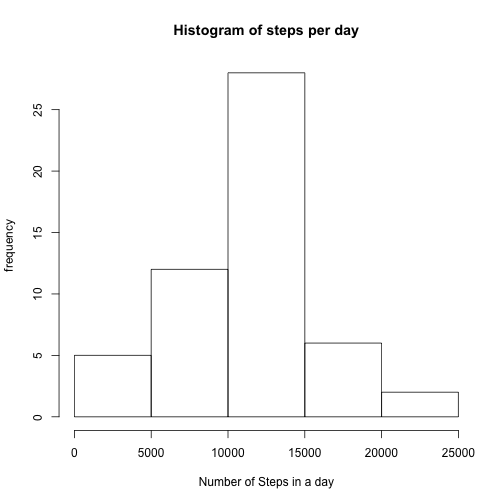

```r
hist(stepsinday[, 2], main = "Histogram of steps per day", xlab = "Number of Steps in a day",
    ylab = "frequency")
```

```r
mean(stepsinday[, 2])
```

```
## [1] 10766
```

```r
median(stepsinday[, 2])
```

```
## [1] 10765
```

## Mean daily activity

Now we will go on to calculating the mean over each time interval. Here we are ignoring the NA values.

```r
timesofday <- aggregate(activity$steps, list(timeofday = activity$interval),
    mean, na.rm = TRUE)
timesofdayts <- ts(timesofday[, 2])
max(timesofday[, 2])
```

```
## [1] 206.2
```

The maximum number of steps is 206.2. We now plot these average steps:

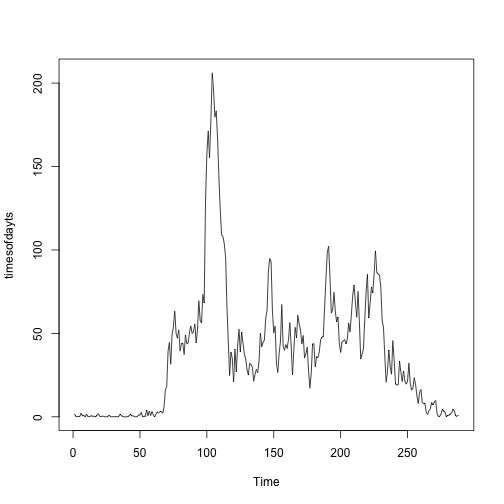

```r
plot.ts(timesofdayts)
```

## Inputting Missing values

We first calculate the number of rows in the original data with NA's in them:

```r
missing <- nrow(activity) - nrow(goodactivity)
(missing/nrow(activity)) * 100
```

```
## [1] 13.11
```

This is the percentage of the number of rows with NAs in the original data. In the code below, we replace each NA in the original data, by the average number of steps for that time period.

```r
for (i in 1:nrow(activity)) {
    if (is.na(activity[i, 1])) {
        time <- activity[i, 3]
        j <- which(timesofday[, 1] == time)
        activity[i, 1] <- timesofday[j, 2]
    }
}
```

Now we will count the number of steps in a day with this fixed up data:

```r
dates<-numeric(length=100)
steps<-numeric(length=100)
stepsinday <- data.frame(dates,steps)
day<-as.Date("2012-10-01")
j<-1
stepsinday[j,1]<-day
for (i in 1:nrow(activity)){
      #if we are in the same day, we won't change the day,
      # but just add the number of steps
      if (as.Date(activity[i,2])==day){
            stepsinday[j,2]<-stepsinday[j,2]+activity[i,1]
            }
      #if the day has changed, we go to the next row in stepsinday and start
      #ading the number of steps
      else {j<-j+1
            day<-as.Date(activity[i,2])
            stepsinday[j,1]<-day
            stepsinday[j,2]<-stepsinday[j,2]+activity[i,1]
            }
      }
stepsinday[stepsinday==0] <- NA
stepsinday<-na.omit(stepsinday)
```

Here are the mean and median of the number of steps per day with the fixed up data:

```r
mean(stepsinday[, 2])
```

```
## [1] 10766
```

```r
median(stepsinday[, 2])
```

```
## [1] 10766
```

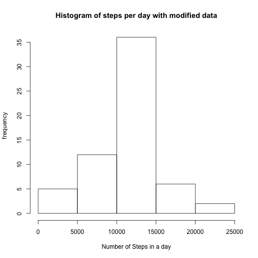

```r
hist(stepsinday[, 2], main = "Histogram of steps per day with modified data",
    xlab = "Number of Steps in a day", ylab = "frequency")
```

```r
dates <- activity[, 2]
weekday <- weekdays(as.Date(dates))
wkend <- weekday == "Saturday" | weekday == "Sunday"
weekday[wkend] <- "weekend"
weekday[!wkend] <- "workingday"
newactivity <- cbind(activity, weekday)
```

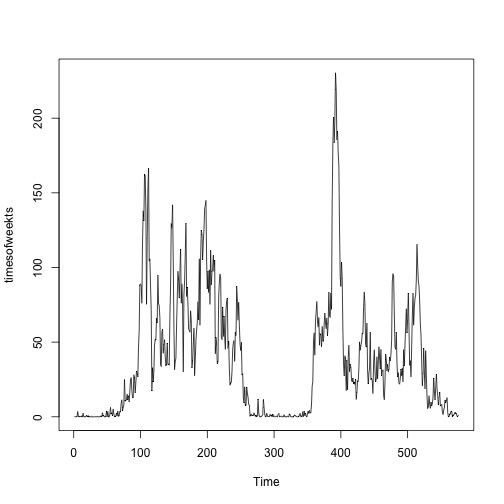

```r
timesofdaywkg <- aggregate(activity$steps, list(timeofday = activity$interval,
    weekday = newactivity[, 4] == "workingday"), mean)
timesofweekts <- ts(timesofdaywkg[, 3])
plot.ts(timesofweekts)
```

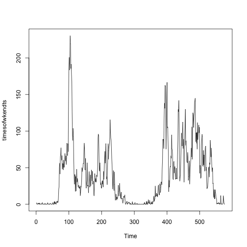

```r
timesofdaywkend <- aggregate(activity$steps, list(timeofday = activity$interval,
    weekday = newactivity[, 4] == "weekend"), mean)
timesofwkendts <- ts(timesofdaywkend[, 3])
plot.ts(timesofwkendts)
```